# Razpoložljiva količina kmetijskih proizvodv

Author

Miha Prajs

Published

June 12, 2024

## Bilanca proizvodnje in potrošnje kmetijskih proizvodov

Leta 2023 je bilo prebivalcu Slovenije na voljo povprečno 132 kg sadja, 112 kg žit, 101 kg zelenjave, 87 kg mesa, 74 kg krompirja, 11 kg jajc, 6 kg riža in 1 kg medu na prebivalca. V primerjavi s pejšnjim letom se je povečala razpoložljiva količia za 7 % pri rižu, 3 % pri krompirju in skoraj 2 % pri jajcih, medtem ko se je količina medu zmanjšala za 21 %, žit in zelenjave za 3 % ter za 1 % pri sadju. Količina mesa za prehrano je ostala na primerljivi ravni kot v prejšnjem letu (Habjanič 2024).

## Kje najdemo podatke?

Od leta 2000 Statistični urad Republike Slovenije (SURS) zbira podatke o razpoložljivih količinah kmteiskih proizvodov namenjenih prehrani prebivalstva na prebivalca.

SURS vse zbrane podatke objavljavlja oz. posodablja v podatkovni bazi [SiStat](https://pxweb.stat.si/SiStat/sl). Podatke o razpoložljivi količini kmetijskih proizvodov za prehrano na prebivalca pa najdemo na povezavi: pxweb.stat.si/SiStatData/pxweb/sl/Data/-/H206S.px.

## Rezultati

```r
library(tidyverse)
library(esquisse)
```

```r
df<-read.csv("H206S_20240612-163643.csv") %>%
  rename("Leto"="LETO") %>%
  arrange(desc(Leto))
df %>% head(10)
```

```
   Leto   Zita  Meso Jajca Krompir Zelenjava  Med  Riz  Sadje
1  2023 112.25 86.93 11.14   74.01    101.11 1.01 5.81 131.61
2  2022 115.72 87.09 10.97   71.59    104.25 1.27 5.43 133.57
3  2021 116.58 88.97 10.80   63.16    118.51 0.62 4.94 108.72
4  2020 116.30 87.72 10.38   63.72    118.89 0.92 5.41 128.98
5  2019 120.40 90.77 11.66   61.97    117.54 0.70 4.80 127.86
6  2018 123.30 92.60 10.85   66.49    111.41 1.07 4.48 152.48
7  2017 120.97 93.08 11.52   68.00    113.97 0.87 4.71 121.62
8  2016 121.41 94.22 10.67   68.51    113.41 1.07 4.97 122.69
9  2015 120.89 88.31 11.13   68.32    109.88 1.41 4.94 134.23
10 2014 119.27 84.99  9.78   62.37    103.92 1.14 5.62 131.06
```

Iz zgornje tabele je razvidno, da so podatki razdeljeni v naslednje skupine:

- Žita,
- Meso,
- Jajca,
- Krompir,
- Zelenava,
- Med,
- Riž,
- Sadje.

Takoj lahko opazimo, da je nekaterih proizvodov bistveno več kot drugih. Med poizvodi, ki jih je navoljo naječ, iztopa sadje z 131,61 kg/prebivalca, med tistimi, ki jih je najmanj, pa iztopa med z le 1,01 kg/prebilvalca.

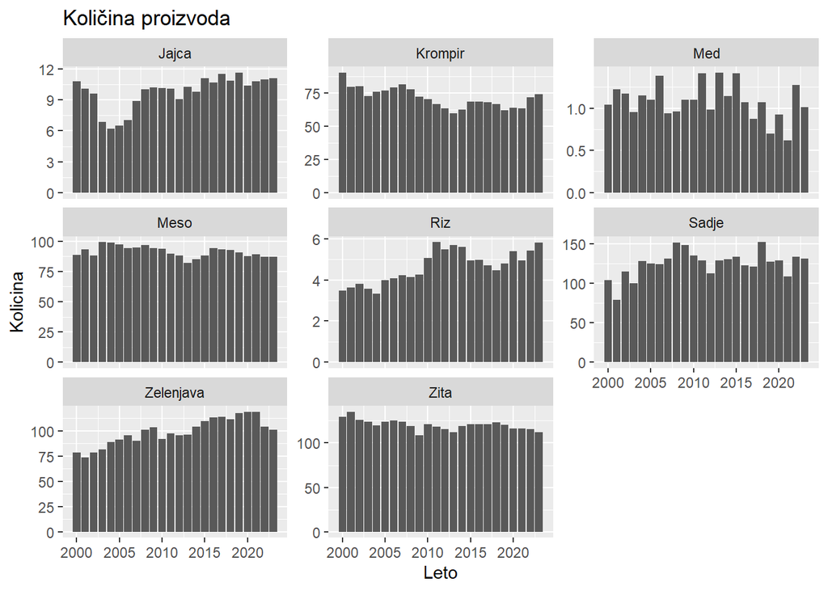

```r
df %>%
  pivot_longer(cols=-Leto,names_to="Proizvod",values_to="Kolicina") %>%
  ggplot(aes(x=Leto,y=Kolicina))+
  geom_col()+
  facet_wrap(~Proizvod,scales="free_y")+
  labs(title="Količina proizvoda")
```

Zgornji grafi prikazujejo količino posameznih proivodov skozi leta. Vidimo lahko, da se količine v večini ne spreminjajo drastično, le med ima velike skoke posamezna leta.

```r
df1<-df %>%
  pivot_longer(cols=-Leto,names_to="Proizvod",values_to="Kolicina") %>%
  group_by(Leto) %>%
  summarise("Kolicina hrane na prebivalca"=sum(Kolicina))
df1
```

```
# A tibble: 24 × 2
    Leto `Kolicina hrane na prebivalca`
   <int>                          <dbl>
 1  2000                           507.
 2  2001                           475.
 3  2002                           502.
 4  2003                           488.
 5  2004                           522.
 6  2005                           526.
 7  2006                           531.
 8  2007                           536.
 9  2008                           561.
10  2009                           542.
# ℹ 14 more rows
```

V zgornji tabeli so prikazane skupne količine kmetijskih proizvodov na prebivalca za posamezna leta, razlike med posameznimi leti pa so bolj vidne na spodnjem grafu.

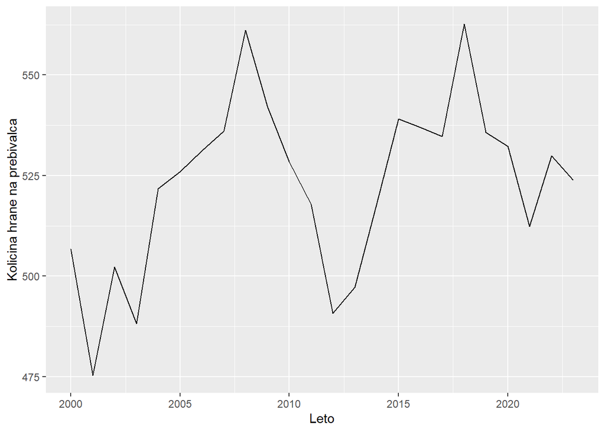

```r
df1 %>%
  ggplot(aes(y=`Kolicina hrane na prebivalca`,x=Leto))+
  geom_line()
```

```r
df %>%
  summarise("Povp. kolicina žit"=mean(Zita),
            "Povp. kolicina mesa"=mean(Meso),
            "Povp. kolicina jajc"=mean(Jajca),
            "Povp. kolicina krompirja"=mean(Krompir),
            "Povp. kolicina zelenjave"=mean(Zelenjava),
            "Povp. kolicina medu"=mean(Med),
            "Povp. kolicina riža"=mean(Riz),
            "Povp. kolicina sadja"=mean(Sadje))
```

```
  Povp. kolicina žit Povp. kolicina mesa Povp. kolicina jajc
1           120.3958            91.35583            9.784583
  Povp. kolicina krompirja Povp. kolicina zelenjave Povp. kolicina medu
1                 71.33625                 98.99958            1.083333
  Povp. kolicina riža Povp. kolicina sadja
1            4.657083             125.3308
```

V zadnjih 24 letih je bilo na trgu posamzenemu prebivalcu na voljo največ sadja, povprečno 125,33 kg na leto, in najmanj medu, v povprečju 1,1 kg na leto.

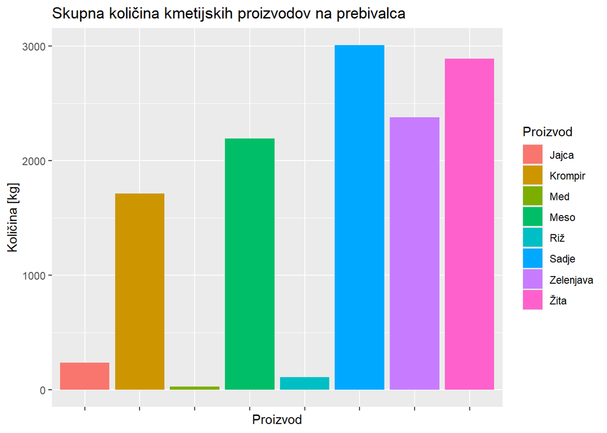

```r
df %>%
  summarise("Žita"=sum(Zita),
            "Meso"=sum(Meso),
            "Jajca"=sum(Jajca),
            "Krompir"=sum(Krompir),
            "Zelenjava"=sum(Zelenjava),
            "Med"=sum(Med),
            "Riž"=sum(Riz),
            "Sadje"=sum(Sadje)) %>%
  pivot_longer(everything(),names_to="Proizvod",values_to="Kolicina") %>%
  ggplot(aes(x=Proizvod,y=Kolicina,fill=Proizvod))+
  geom_bar(stat="identity")+
  theme(axis.text.x=element_blank())+
  labs(title="Skupna količina kmetijskih proizvodov na prebivalca",
       x="Proizvod",
       y="Količina [kg]")
```

V zadnjih 24 letih je bilo na trgu posamzenemu prebivalcu na voljo največ sadja, povprečno 125,33 kg na leto, in najmanj medu, v povprečju 1,1 kg na leto.

## Zaključek

Ugotovili smo, da je bilo povprečnemu Slovencu navoljo največ sadja in žit ter najmanj medu in riža. Skupaj mu je bilo vsako leto navoljo več kot 450 kg kmetijskih proizvodov.

## Viri

Habjanič, Andraž. 2024. “Stopnji Samooskrbe z Medom in Sadjem Lani Nizki.” https://www.stat.si/StatWeb/News/Index/12695.